# NIST_1.3

Sakaguchi

2025-07-10

# [EDA Techniques](https://www.itl.nist.gov/div898/handbook/eda/section3/eda3.htm)

- **Summary**
  - データセットを収集後、探索的データ解析をどのように進めるか?
  - あまたある技術の何に焦点を当てたらよいか?
  - 期待するのはどのような結論か?
  - 本章
    - EDA技術紹介を通してこれらの疑問に答え
    - 各技術の詳細を記述
    - グラフィカル、定量的な技術の両方に触れる
    - EDAでは主にグラフ技法に重点
- **第3章の目次**
  1. [導入](https://www.itl.nist.gov/div898/handbook/eda/section3/eda31.htm)
  2. [分析の議題](https://www.itl.nist.gov/div898/handbook/eda/section3/eda32.htm)
  3. [グラフ技術: アルファベット順](https://www.itl.nist.gov/div898/handbook/eda/section3/eda33.htm)
  4. [グラフ化技術: 課題分類](https://www.itl.nist.gov/div898/handbook/eda/section3/eda34.htm)
  5. [定量手法: アルファベット順](https://www.itl.nist.gov/div898/handbook/eda/section3/eda35.htm)
  6. [確率分布](https://www.itl.nist.gov/div898/handbook/eda/section3/eda36.htm)

## [1.3.1. Introduction](https://www.itl.nist.gov/div898/handbook/eda/section3/eda31.htm)

- **グラフィカルと定量的手法**
  - 多くの探索的、古典的データ分析の技法を紹介していく章
  - 網羅的なリストではない
  - その他ある技法は他の章で述べられる
  - 具体例
    - [製品比較](https://www.itl.nist.gov/div898/handbook/prc/prc.htm)では古典的統計手法の多くを紹介
  - EDAはグラフ技法に重点をおき、古典的技法は定量手法に置く
  - 実践上は、グラフと定量技法を併せて使用
  - 本章では、グラフ、定量的技法の記述に分けて説明
    - 分類分けを明確にする為の区分け
    - データ分析の際、グラフ、定量的技法の併用を進めないということではない
- **ケーススタディで使用する技法**
  - 本章は、技法そのものに重点を置く
    - グラフ、検定の定義、公表された参考文献、出力例について
    - 技法の使用と質問への解答はケーススタディにて
      - ケーススタディですべての技術が示されるわけではない
- **利用可能なソフトウエア**
  - (NISTサイトはDataplotとR)
    - Rと出来ればPythonも将来的に補完していきたい

## [1.3.2. Analysis Questions](https://www.itl.nist.gov/div898/handbook/eda/section3/eda32.htm)

- **EDA議題**
  - 探索的データ解析が解答してきた課題は概ね以下
    1. 代表値はなにか
    2. 代表値の不確かさは
    3. 数のセットによくフィットする分布は
    4. パーセンタイルとは
    5. 技術的修正は効果あるか
    6. 因子がもつ効果は
    7. 最重要の因子は
    8. 異なる試験所から得られた測定が等価か
    9. 応答変数と説明変数の集合を関連付ける最も適した関数は
    10. 因子の最良設定は
    11. 時間依存ノイズ由来のシグナルを分離可能か
    12. 多変数データからの構造を抽出できるか
    13. データに外れ値はあるか
- **分析者は工学的問題に関連する課題を特定すべき**
  - あらゆる分析の重要な初期段階
    - 目下の工学的問題に対して上のどれが関連するかの特定
      - 解答をしたい課題
      - どの質問が目下の問題と関係ないか?
    - これらの疑問のセットをまとめた後、重要度高い順に優先順位付け
      - 集中力を維持するために非常に重要なステップ
    - EDA技法はこれらの各質問に紐づいている
      - いくつかのEDA技法は幅広くほぼ例外なく使用
        - 散布図等
    - 一方で、特定の質問に紐づいたEDA技法も数多く存在
    - 関連する質問を明示的に特定しないと選択した場合
      - 質問に固有のEDA技術を活用出来ない
- **EDAアプローチの重点であるグラフ**
  - ここでの疑問のほとんどは本章で取り上げる技術で解決可能
  - [プロセスモデル](https://www.itl.nist.gov/div898/handbook/pmd/pmd.htm)と [プロセス改善](https://www.itl.nist.gov/div898/handbook/pri/pri.htm) の章でも上の疑問の多くに対処可能
  - これら疑問は古典的統計学へのアプローチにも関連
  - EDAとは何が違うか?
    - EDAは洞察を得るためのグラフ技術に重点
    - 古典的アプローチは定量的な検定に重点
  - **分析者の多くはグラフと古典的定量的技法を併せて問題へ取り組む**

## [1.3.4. Graphical Techniques: By Problem Category](https://www.itl.nist.gov/div898/handbook/eda/section3/eda34.htm)

- カテゴリ毎に紹介
  - 単変量y = c + e
  - 時系列y = f(t) + e
  - 1因子y = f(x) + e
  - 多因子/比較y = f(xp, x1,x2,…,xk) + e
  - 多因子/スクリーニングy = f(x1,x2,x3,…,xk) + e
  - 回帰y = f(x1,x2,x3,…,xk) + e
  - ラボ間比較(y1,y2) = f(x) + e
  - 多変量(y1,y2,…,yp)

## [1.3.3.25. Run-Sequence Plot](https://www.itl.nist.gov/div898/handbook/eda/section3/runseqpl.htm)

- **目的: 位置のシフト有無、スケール、外れ値の確認**
  - ランシーケンスプロット(Chambers 1983)
    - 単変数データセットを容易にグラフ的要約可能な方法
    - 単変数データセット共通の仮定
      1. 無作為性
      2. 固定分布
      3. 一貫した位置
      4. 一貫したスケール
    - これらに対してランシーケンスプロットが位置のシフト、スケール変化をきわめて明示的に示す
    - 外れ値も容易に検出可能
- **サンプルプロット: 最後1/3のデータが位置シフト**

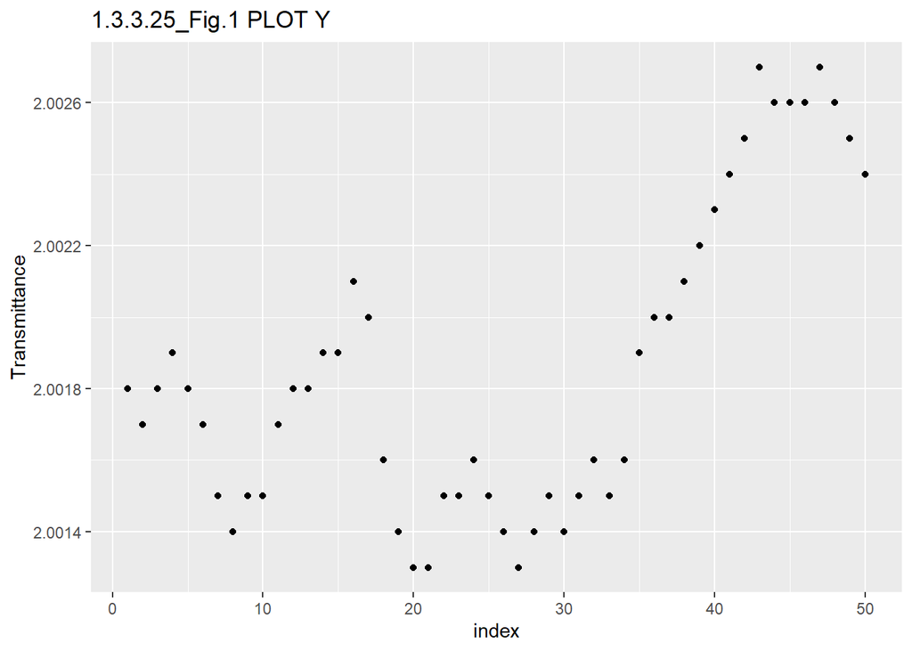

```r
data <- read.table("https://www.itl.nist.gov/div898/handbook/datasets/MAVRO.DAT", skip=25)
x <- c(1:length(data$V1))
plt <- ggplot(data=data, aes(x=x, y=V1)) + geom_point() +
  labs(title="1.3.3.25_Fig.1 PLOT Y", x="index", y="Transmittance") +
  scale_y_continuous(breaks=seq(2.0010, 2.0030, 0.0004))
plt
```

- このサンプルプロット
  - データは[the MAVRO.DAT data set](https://www.itl.nist.gov/div898/handbook/datasets/MAVRO.DAT)より
  - 最後1/3のデータで位置のシフトが見て取れる
- **定義: $y_i$ vs i**
  - グラフの見方
    - 縦軸: 応答変数$Y_i$
    - 横軸: データの順番i(i=1,2,3,…)
- **問い**
  - ランシーケンスプロットは以下の問いに解答可
    1. 位置シフトあるか
    2. 変動のシフトはあるか
    3. 外れ値存在するか
  - ランシーケンスプロットはまた、分析者にデータへのよい感覚をもたらす
- **重要: 単変量という仮定の確認**
  - 単変量データにおける既定モデル
    - Y = constant + error
  - 誤差は無作為、固定分布、固定位置と尺度と仮定
  - モデルの妥当性はこの誤差に関する仮定による
    - ランシーケンスプロットは固定位置と尺度の確認に有用
  - より複雑なモデルにおいてさえ、誤差項に関するこの仮定は同じであることが多い
  - 残差(非常に複雑なモデルからでも)のランシーケンスプロット
    - 外れ値、位置と尺度のシフト確認に重要な役割
- **関連技術**
  - [散布図](https://www.itl.nist.gov/div898/handbook/eda/section3/scatterp.htm)
  - [ヒストグラム](https://www.itl.nist.gov/div898/handbook/eda/section3/histogra.htm)
  - [自己相関プロット](https://www.itl.nist.gov/div898/handbook/eda/section3/autocopl.htm)
  - [ラグプロット](https://www.itl.nist.gov/div898/handbook/eda/section3/lagplot.htm)
- **ケーススタディ**
  - ランシーケンスプロット実例は[フィルター透過度](https://www.itl.nist.gov/div898/handbook/eda/section4/eda426.htm)のケーススタディで
- **ソフトウエア**
  - 統計ソフトウエアプログラムの最も一般的な適用

## [1.3.3.15. Lag Plot](https://www.itl.nist.gov/div898/handbook/eda/section3/lagplot.htm)

- **目的: 無作為性の確認**
  - データセット、時系列データに対して無作為性の確認
  - 無作為データの場合、ラグプロット上で特定可能な構造を示さない
  - 非無作為構造
    - 根底にあるデータは無作為ではない
  - よくあるパターンを以下に例で示す
- **サンプルプロット**

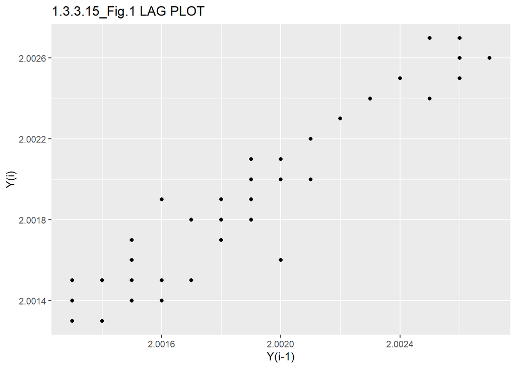

```r
data <- read.table("https://www.itl.nist.gov/div898/handbook/datasets/MAVRO.DAT", skip=25)
plt <- ggplot(data=data, aes(x=lag(V1,1), y=V1)) + geom_point() +
  labs(title="1.3.3.15_Fig.1 LAG PLOT", x="Y(i-1)", y="Y(i)") +
  scale_y_continuous(breaks=seq(2.0010, 2.0030, 0.0004))
plt
```

- このラグプロットサンプルはデータは[the MAVRO.DAT data set](https://www.itl.nist.gov/div898/handbook/datasets/MAVRO.DAT)より ‐ 線形パターンが見て取れる
  - 非無作為であることを強く示唆
  - 自己相関モデルが当てはまるのではとの示唆
- **定義**
  - ラグは固定された時間的ずれ
    - 例えばY2とY7があればラグは7-2=**5**
  - 任意のラグでグラフ生成出来るが、通常はラグ1を使用
  - Y軸: Y(i) for all i
  - X軸: Y(i-1) for all i
- **問い**
  - ラグプロットは以下疑問に答えてくれる
    1. データは無作為(抽出)であるか
    2. データの系統内で相関あるか
    3. データに適するモデルは?
    4. 外れ値はデータにあるか
- **重要**
  - 統計推定、検定手法のほとんどで無作為性が基本仮定にあり
  - ラグプロットは研究者にとって日常的ツールであるべき
- **例**
  - 1.3.3.15.1 ~ 1.3.3.15.4 で見ていく
- **関連技術**
  - [自己相関プロット](https://www.itl.nist.gov/div898/handbook/eda/section3/autocopl.htm)
  - [スペクトル](https://www.itl.nist.gov/div898/handbook/eda/section3/spectrum.htm)
  - [ラン検定](https://www.itl.nist.gov/div898/handbook/eda/section3/eda35d.htm)
- **ケーススタディ**
  - [ビーム偏向](https://www.itl.nist.gov/div898/handbook/eda/section4/eda425.htm)で実例見ていく
- **ソフトウエア**
  - ラグプロットを直接使用可能な統計ソフトウエアはない
  - 本質的には2変数の散布図
    - マクロ記述により多くの統計プログラムで使用可能に

## [1.3.3.15.1. Lag Plot: Random Data](https://www.itl.nist.gov/div898/handbook/eda/section3/eda33f1.htm)

- **ラグプロット**

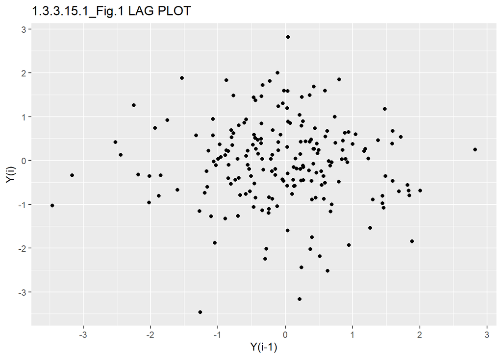

```r
data <- read.table("https://www.itl.nist.gov/div898/handbook/datasets/NORMAL2.DAT", skip=25)
plt <- ggplot(data=data, aes(x=lag(V1,1), y=V1)) + geom_point() +
  labs(title="1.3.3.15.1_Fig.1 LAG PLOT", x="Y(i-1)", y="Y(i)") +
  scale_x_continuous(breaks=seq(-4, 3, 1)) +
  scale_y_continuous(breaks=seq(-3, 3, 1))
plt
```

- **結論**
  - 200個の正規乱数から作成した上記プロットから以下結論を得る
    1. データは無作為
    2. 自己相関は見られない
    3. 外れ値もない
- **議論**
  - 上記はlag=1で作成したプロット
  - 特定の構造は見られない
  - ある値$Y_{i-1}$から$Y_i$の値を推測出来ない
  - この無関係さが無作為性の本質

## [1.3.3.15.2. Lag Plot: Moderate Autocorrelation](https://www.itl.nist.gov/div898/handbook/eda/section3/eda33f2.htm)

- **ラグプロット**

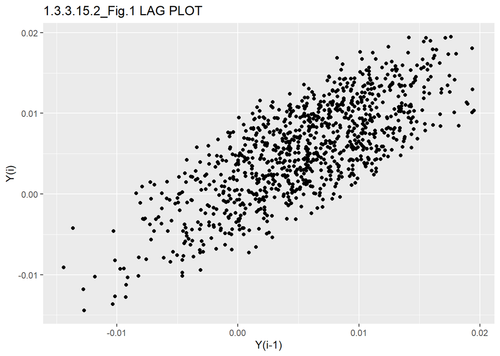

```r
data <- read.table("https://www.itl.nist.gov/div898/handbook/datasets/FLICKER.DAT", skip=25)
plt <- ggplot(data=data, aes(x=lag(V1,1), y=V1)) + geom_point() +
  labs(title="1.3.3.15.2_Fig.1 LAG PLOT", x="Y(i-1)", y="Y(i)") +
  scale_x_continuous(breaks=seq(-0.02, 0.02, 0.01)) +
  scale_y_continuous(breaks=seq(-0.02, 0.02, 0.01))
plt
```

## [1.3.3.15.3. Lag Plot: Strong Autocorrelation and Autoregressive Model](https://www.itl.nist.gov/div898/handbook/eda/section3/eda33f3.htm)

- **ラグプロット**

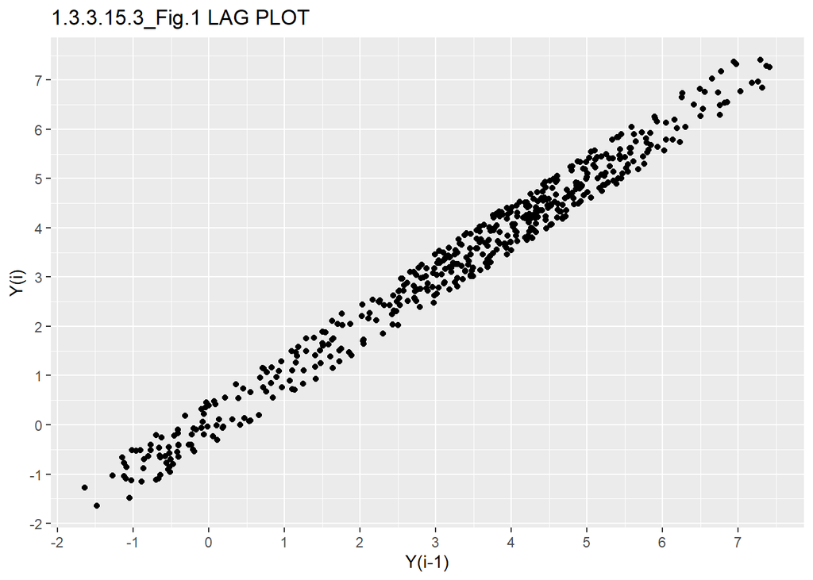

```r
data <- read.table("https://www.itl.nist.gov/div898/handbook/datasets/RANDWALK.DAT", skip=25)
plt <- ggplot(data=data, aes(x=lag(V1,1), y=V1)) + geom_point() +
  labs(title="1.3.3.15.3_Fig.1 LAG PLOT", x="Y(i-1)", y="Y(i)") +
  scale_x_continuous(breaks=seq(-2, 8, 1)) +
  scale_y_continuous(breaks=seq(-2, 8, 1))
plt
```

## [1.3.3.15.4. Lag Plot: Sinusoidal Models and Outliers](https://www.itl.nist.gov/div898/handbook/eda/section3/eda33f4.htm)

- **ラグプロット**

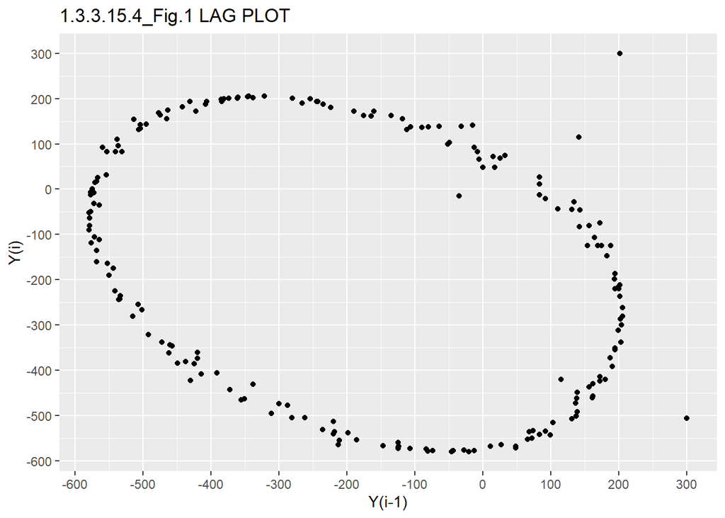

```r
data <- read.table("https://www.itl.nist.gov/div898/handbook/datasets/LEW.DAT", skip=25)
plt <- ggplot(data=data, aes(x=lag(V1,1), y=V1)) + geom_point() +
  labs(title="1.3.3.15.4_Fig.1 LAG PLOT", x="Y(i-1)", y="Y(i)") +
  scale_x_continuous(breaks=seq(-700, 400, 100)) +
  scale_y_continuous(breaks=seq(-700, 400, 100))
plt
```